# 🎯 PHÂN TÍCH CÁC YẾU TỐ ẢNH HƯỞNG ĐẾN KHẢ NĂNG RỜI ĐI (EXIT) CỦA NGÂN HÀNG

📌 Mục tiêu chính của dự án

Xác định các yếu tố then chốt dẫn đến hành vi ngừng sử dụng dịch vụ để từ đó xây dựng mô hình dự báo nhằm giảm thiểu tỷ lệ mất mát khách hàng.

# DATA PREPARING

```python
import kagglehub

# Download latest version
path = kagglehub.dataset_download("tranhuunhan/vietnam-bank-churn-dataset-2025")

print("Path to dataset files:", path)
```

[output not shown]

```python
import os

directory = os.listdir(path)
subdir = f"{path}/{directory[0]}"
subdir
```

```
'/kaggle/input/vietnam-bank-churn-dataset-2025/bank_churn_dataset_80k.csv'
```

```python
import pandas as pd

data = pd.read_csv(subdir)
data.head(5)
```

|  | id | full_name | credit_sco | gender | age | occupation | balance | monthly_ir | address | origin_province | ... | last_transaction_month | created_date | exit | customer_segment | engagement_score | loyalty_level | digital_behavior | risk_score | risk_segment | cluster_group |
| --- | --- | --- | --- | --- | --- | --- | --- | --- | --- | --- | --- | --- | --- | --- | --- | --- | --- | --- | --- | --- | --- |
| 0 | 1 | Đặng Văn Vũ | 725 | male | 55 | Chủ Doanh nghiệp nhỏ | 177306004 | 121000000 | Phường An Hội (BT) | TP. Hồ Chí Minh | ... | 91038993 | 27/02/2025 | False | Priority | 90 | Bronze | mobile | 0.0359 | Low | 4 |
| 1 | 2 | Bùi Hữu Phúc | 689 | male | 45 | Nội trợ/Sinh viên | 1927416 | 5000000 | Phường Bến Thành (Q1) | Đồng Nai | ... | 3255569 | 29/07/2021 | False | Mass | 63 | Gold | mobile | 0.2664 | Low | 2 |
| 2 | 3 | Lê Văn Mai | 702 | female | 44 | Chủ Doanh nghiệp nhỏ | 304931745 | 109000000 | Phường Hòa Bình (Q11) | TP. Hồ Chí Minh | ... | 0 | 03/03/2021 | False | Priority | 36 | Silver | offline | 0.1343 | Low | 4 |
| 3 | 4 | Dương Trần Nhiên | 766 | male | 44 | Chủ Doanh nghiệp nhỏ | 50615501 | 79000000 | Phường 7 (Q7) | TP. Hồ Chí Minh | ... | 0 | 12/02/2022 | False | Priority | 23 | Bronze | offline | 0.2185 | Low | 4 |
| 4 | 5 | Dương Thu Linh | 677 | female | 77 | Giáo viên/Giảng viên | 40532432 | 25000000 | Phường Thắng Lợi (Q10) | TP. Hồ Chí Minh | ... | 0 | 24/07/2022 | False | Emerging | 23 | Bronze | offline | 0.2942 | Low | 2 |

5 rows × 26 columns

```python
# Import các thư viện cần thiết
import numpy as np
import matplotlib.pyplot as plt
import seaborn as sns
```

# DATA CLEANING

```python
data.columns
```

```
Index(['id', 'full_name', 'credit_sco', 'gender', 'age', 'occupation',
       'balance', 'monthly_ir', 'address', 'origin_province', 'tenure_ye',
       'married', 'nums_card', 'nums_service', 'active_member',
       'last_active_date', 'last_transaction_month', 'created_date', 'exit',
       'customer_segment', 'engagement_score', 'loyalty_level',
       'digital_behavior', 'risk_score', 'risk_segment', 'cluster_group'],
      dtype='object')
```

```python
# Kiểm tra kiểu dữ liệu
data.info()
```

```
<class 'pandas.core.frame.DataFrame'>
RangeIndex: 80000 entries, 0 to 79999
Data columns (total 26 columns):
 #   Column                  Non-Null Count  Dtype
---  ------                  --------------  -----
 0   id                      80000 non-null  int64
 1   full_name               80000 non-null  object
 2   credit_sco              80000 non-null  int64
 3   gender                  80000 non-null  object
 4   age                     80000 non-null  int64
 5   occupation              80000 non-null  object
 6   balance                 80000 non-null  int64
 7   monthly_ir              80000 non-null  int64
 8   address                 80000 non-null  object
 9   origin_province         80000 non-null  object
```

[output cut: 18 more lines]

```python
# Đưa về kiểu dữ liệu đúng
data['last_active_date'] = pd.to_datetime(data['last_active_date'],format='%d/%m/%Y')
data['created_date'] = pd.to_datetime(data['created_date'],format='%d/%m/%Y')

print(data['last_active_date'].dtype,data['created_date'].dtype,sep=',')
```

```
datetime64[ns],datetime64[ns]
```

```python
# Loại bỏ những cột không có giá trị phân tích
data = data.drop(columns=['id','origin_province','full_name','married'],axis=1)
data.columns
```

```
Index(['credit_sco', 'gender', 'age', 'occupation', 'balance', 'monthly_ir',
       'address', 'tenure_ye', 'nums_card', 'nums_service', 'active_member',
       'last_active_date', 'last_transaction_month', 'created_date', 'exit',
       'customer_segment', 'engagement_score', 'loyalty_level',
       'digital_behavior', 'risk_score', 'risk_segment', 'cluster_group'],
      dtype='object')
```

```python
# Kiểm tra dư liệu null
data.isnull().sum()
```

|  | 0 |
| --- | --- |
| credit_sco | 0 |
| gender | 0 |
| age | 0 |
| occupation | 0 |
| balance | 0 |
| monthly_ir | 0 |
| address | 0 |
| tenure_ye | 0 |
| nums_card | 0 |
| nums_service | 0 |
| active_member | 0 |
| last_active_date | 0 |
| last_transaction_month | 0 |
| created_date | 0 |
| exit | 0 |
| customer_segment | 0 |
| engagement_score | 0 |
| loyalty_level | 0 |
| digital_behavior | 0 |
| risk_score | 0 |
| risk_segment | 0 |
| cluster_group | 0 |

**dtype:** int64

=> KHÔNG CÓ GIÁ TRỊ BỊ THIẾU

```python
data.describe()
```

|  | credit_sco | age | balance | monthly_ir | tenure_ye | nums_card | nums_service | last_active_date | last_transaction_month | created_date | engagement_score | risk_score | cluster_group |
| --- | --- | --- | --- | --- | --- | --- | --- | --- | --- | --- | --- | --- | --- |
| count | 80000.000000 | 80000.000000 | 8.000000e+04 | 8.000000e+04 | 80000.000000 | 80000.000000 | 80000.000000 | 80000 | 8.000000e+04 | 80000 | 80000.000000 | 80000.000000 | 80000.000000 |
| mean | 684.321137 | 49.381862 | 6.118320e+07 | 3.778820e+07 | 1.777250 | 2.634688 | 3.564425 | 2024-05-16 17:51:38.880000256 | 8.831755e+06 | 2023-04-02 09:35:15.719999744 | 31.725400 | 0.269260 | 1.971037 |
| min | 495.000000 | 20.000000 | 4.086630e+05 | 3.000000e+06 | 0.000000 | 1.000000 | 1.000000 | 2021-01-16 00:00:00 | 0.000000e+00 | 2021-01-01 00:00:00 | 7.000000 | 0.017300 | 1.000000 |
| 25% | 649.000000 | 38.000000 | 1.462592e+07 | 1.400000e+07 | 1.000000 | 2.000000 | 2.000000 | 2023-10-11 00:00:00 | 0.000000e+00 | 2022-02-17 00:00:00 | 16.000000 | 0.200400 | 1.000000 |
| 50% | 682.000000 | 47.000000 | 3.090276e+07 | 2.300000e+07 | 2.000000 | 2.000000 | 3.000000 | 2024-08-28 00:00:00 | 0.000000e+00 | 2023-04-03 00:00:00 | 22.000000 | 0.277400 | 2.000000 |
| 75% | 718.000000 | 58.000000 | 6.960994e+07 | 4.700000e+07 | 3.000000 | 3.000000 | 5.000000 | 2025-03-13 00:00:00 | 0.000000e+00 | 2024-05-17 00:00:00 | 38.000000 | 0.338900 | 2.000000 |
| max | 800.000000 | 90.000000 | 1.000000e+09 | 2.160000e+08 | 4.000000 | 5.000000 | 8.000000 | 2025-07-01 00:00:00 | 6.000000e+08 | 2025-07-01 00:00:00 | 100.000000 | 0.540400 | 4.000000 |
| std | 51.169733 | 15.067480 | 8.868620e+07 | 3.655107e+07 | 1.315828 | 1.218556 | 2.002448 | NaN | 3.378683e+07 | NaN | 23.474862 | 0.091891 | 1.040763 |

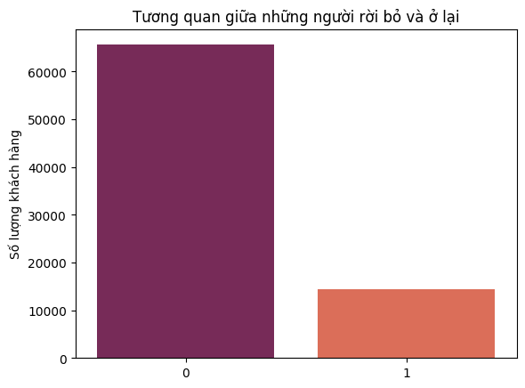

```python
data['exit'] = data['exit'].astype(int)
# Kiểm tra mức độ cân bằng của dữ liệu dựa trên số khách hang rời đi

sns.countplot(data = data, x = 'exit', palette = 'rocket')

plt.title('Tương quan giữa những người rời bỏ và ở lại')

plt.xlabel('')
plt.ylabel('Số lượng khách hàng')

plt.show()
```

NHẬN XÉT :

- Với 80000 mẫu thì nhãn 1 chỉ chiếm khoảng 15000 mẫu hay chỉ khoảng 18%

=> DỮ LIỆU BỊ MẤT CÂN BẰNG NHẸ VÀ VẪN PHÙ HỢP CHO VIỆC PHÂN TÍCH

```python
# Chia tệp khách hàng thành 4 nhóm tuổi khác nhau

bins = [18,26,41,61,120]
labels = ['Gen Z','Millenials','Gen X','Boomers']

data['age_group'] = pd.cut(data['age'],bins = bins,labels=labels,right = False)
(data['age_group'].value_counts(normalize=True)*100).to_frame()
```

| age_group | proportion |
| --- | --- |
| Gen X | 46.89750 |
| Millenials | 29.33125 |
| Boomers | 21.61625 |
| Gen Z | 2.15500 |

Nhận xét

1, Gen X là phân khúc khách hàng lớn nhất với tỷ lệ gần 47%

2, Trong khi đó, độ tuổi lao động vàng cũng có tỷ trọng lớn với hơn 29 %

3, Gen Z là phân khúc khách hàng nhỏ nhất với chỉ hơn 2% tổng khách hàng sử dụng